# act_report

## Act Report

Code section  
Report

Before writing my insights on the cleaned dataframe, let's display the code used to obtain results below

## Code Section

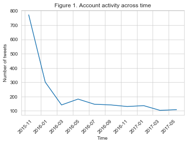

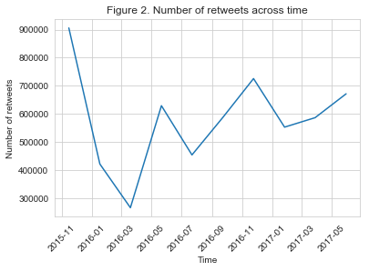

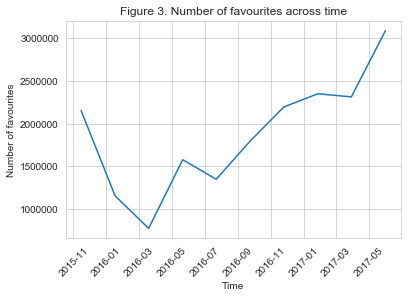

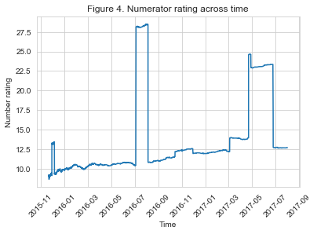

```python
import pandas as pd
import matplotlib.pyplot as plt
import seaborn as sns
%matplotlib inline
sns.set_style("whitegrid")
# Read cleaned data from wrangle_act
archive_df = pd.read_csv('twitter_archive_master.csv')
image_df = pd.read_csv('image_prediction_master.csv')
# After reading a csv, cast timestamps to datetime
archive_df.timestamp = pd.to_datetime(archive_df.timestamp)
archive_df_sorted = archive_df.sort_values(by='timestamp').reset_index()
# Sort the dataframe according to time and bin the dataframe to find patterns across time
start = archive_df_sorted.iloc[0]['timestamp']
end = archive_df_sorted.iloc[-1]['timestamp']
numbins = 11
bins = pd.date_range(start,end,numbins)
archive_df_sorted['timeSlot'] = pd.cut(archive_df_sorted.timestamp, bins,labels=[str(i) for i in range(0,numbins-1)])
archive_df_sorted.groupby('timeSlot').tweet_id.count().values
# Plot number of tweets on each period to find out whether account activity has increased or decreased overtime
plt.figure()
figsize=(12, 10)
plt.plot([b.date() for b in bins[:-1]],archive_df_sorted.groupby('timeSlot').tweet_id.count().values);
plt.title('Figure 1. Account activity across time')
plt.xlabel('Time')
plt.ylabel('Number of tweets')
plt.xticks(rotation=45);
# Plot number of retweets over time
plt.figure()
figsize=(12, 10)
plt.plot([b.date() for b in bins[:-1]],archive_df_sorted.groupby('timeSlot').retw_count.sum().values);
plt.title('Figure 2. Number of retweets across time')
plt.xlabel('Time')
plt.ylabel('Number of retweets')
plt.xticks(rotation=45);
# Plot number of retweets over time
plt.figure()
figsize=(12, 10)
plt.plot([b.date() for b in bins[:-1]],archive_df_sorted.groupby('timeSlot').fav_count.sum().values);
plt.title('Figure 3. Number of favourites across time')
plt.xlabel('Time')
plt.ylabel('Number of favourites')
plt.xticks(rotation=45);
# Plot a MA of the numerator to see if scores are trending downwards or upwards
plt.figure()
figsize=(12, 10)
plt.plot(archive_df_sorted.timestamp, archive_df_sorted.rating_numerator.rolling(100).mean());
plt.title('Figure 4. Numerator rating across time')
plt.xlabel('Time')
plt.ylabel('Number rating')
plt.xticks(rotation=45);
```

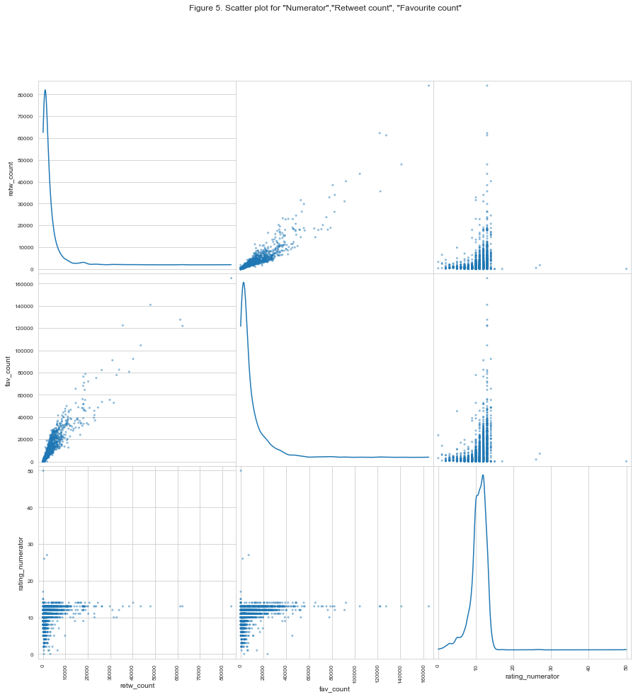

```python
# Correlation between numerator and retw and fav
df_nooutliers = archive_df_sorted.drop(archive_df_sorted[archive_df_sorted['rating_numerator'] > 50].index )
df_corr = df_nooutliers[['retw_count','fav_count','rating_numerator']]
pd.plotting.scatter_matrix(df_corr, figsize=(15,15),diagonal='kde');
plt.suptitle('Figure 5. Scatter plot for "Numerator","Retweet count", "Favourite count"');
```

## Report

#### Introduction

In the following lines I'll try to draw some conclusions for this dataset. Conclusions would have not been made possible if it wasn't for some cleaning operations carried out before in wrangle_act.ipynb. For example, we could not analyse numerator ranking alone if we hadn't made sure that denominators are all equal. Also, some of the plots would not have been possible if it wasn't because all data is available and there are no NaN for some rows.

#### Insights

There are five plots we will describe briefly below

**1 - Figure #1** This figure shows that the account activity has decreased over time. The account owner is tweeting less than it once used to do. However an interpretation could be that a bottom has been found for the number of tweets made for a given period of time and now the account number of tweets per period is sort of stable.

**2 - Figure #2** Even though the number of tweets is in a downtrend or at least in a flat trend recently, it doesn't seem to be the same case for the number of reteweets. It's true that the number of retweets is still less than in the first period, but it gives the impresion that it's peaking up pace. So even though the account is tweeting less, the fact that the account is becoming more popular would probably mean that more people are looking at fewer tweets. The more people looking the more chances that a tweet gets retweet.

**3 - Figure #3** Similar to figure 2, figure 3 shows that number of favourites is also in an upwards trend despite the number of tweets. Again conclusions drawn here are similar. The account is more popular hence drawing more people to look at tweets and hence increasing the number of favourites.

**4 - Figure #4** In figure 4 I wanted to find out whether dogs are differently rated when you compare ratings across time. It seems that either there is a bias towards higher scores or the pictures that I posted more recently portrait better looking dogs... Either way it seems that, leaving outliers aside, ratings for dogs are on the rise!

**5 - Figure #5** Lastly I wanted to find relationships among variables. In this case I wanted to showcase correlations between numerator scoring and favourite and retweet counts. For all of them there seems to be a degree of correlation. Perhaps the most clear is the correlation between favourite and retweet count. Correlation between numerator scoring and the other two show a degree of correlation up to a numerator of around 15. Then there is no correlation whatsoever.

### Conclusions

Getting the above 5 plots was an easy task. Only the x and y variables had to be indicated to plot method. However, this would have not been this easy if hadn't been for the earlier wrangling phase. Favourite and retweet counts were gathered externally and merged with the main dataframe. Also, ratings were standarized and so numerator analysis was the only thing required. Therefore this short section stresses the importance of the **data wrangling** phase to ease EDA